# Initial observations

### INSIGHTS NOTED

- Apple and Garmin are the major players in the high-end sectors with many devices range from 40000 to 80000 rupees.
- Samsung is arguably the only company aiming for the mid-range market with devices ranging from 10000 to 40000 rupees.
- The rest of the brands mostly aims towards the entry-level consumers.

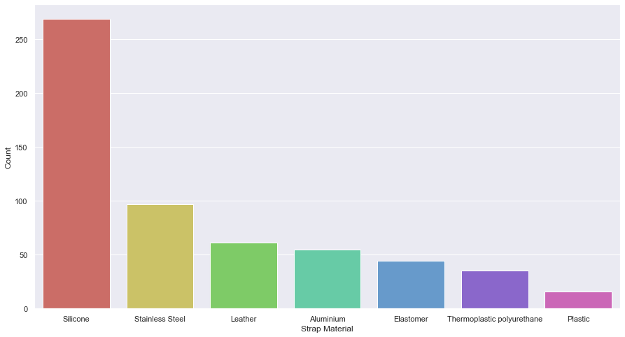

```python
strapDfS = df.groupby(['Strap Material']).size()
strapDf = strapDfS.to_frame()

strapDf['Strap Material'] = strapDfS.index
strapDf.rename(columns={0:'Count'}, inplace = True)
strapDfTop = strapDf.sort_values(by = 'Count', ascending = False)

ax = sns.barplot(x = 'Strap Material', y = 'Count', data=strapDfTop[:7], palette="hls")
```

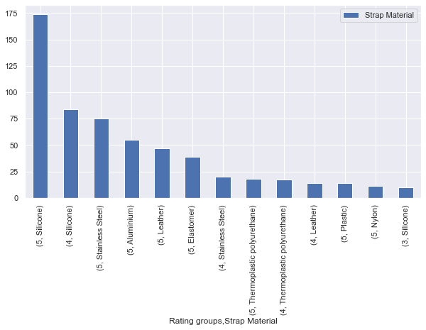

```python
bins = [0, 1, 2, 3, 4, 5]
lab_bin = [1, 2, 3, 4, 5]
df['Rating groups'] = pd.cut(df['Rating'], bins, labels=lab_bin, retbins = False)
df_5 = df[['Strap Material', 'Rating groups']]
df_5 = df.groupby(['Rating groups', 'Strap Material'])['Strap Material'].count().sort_values(ascending = False)
df_5 = df_5.to_frame()
df_5 = df_5[df_5["Strap Material"]>=10]

df_5.plot.bar(figsize = (10, 5))
```

### INSIGHTS NOTED

- Silicone, Stainless Steel and Leather are the 3 most popular types.
- Most of the time, the Silicone strap material is well-received.
- On the other hand, there definitely exist instances where Silicone straps are not that well-rated.
- Alumunium, surprisingly, are well-rated compared to its popularity.

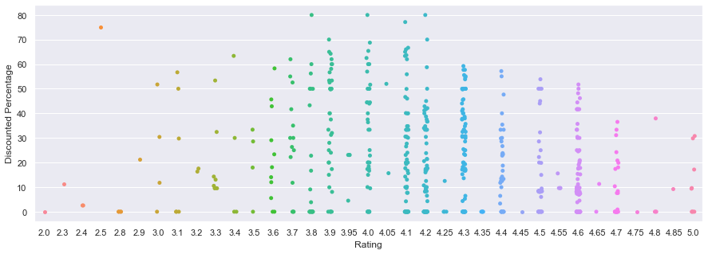

```python
# Distribuion of Rating vs Discounted Percentages

plt.figure(figsize=(15,5))
ax = sns.stripplot(x="Rating", y="Discounted Percentage", data=df)
```

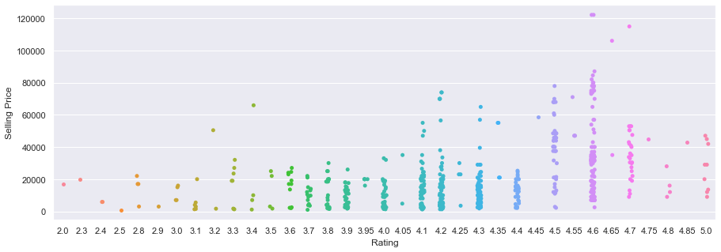

```python
# Distribution of Rating vs Selling Price

plt.figure(figsize=(15,5))
ax = sns.stripplot(x="Rating", y="Selling Price", data=df)
```